# Problem:

## 2.3 Checking if there is any pattern of increase in delay in the starting of the month or month-end.

```python
flight_data["FL_DATE"]=pd.to_datetime(flight_data["FL_DATE"])
```

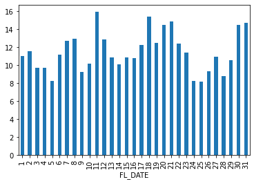

```python
day_delay=flight_data.groupby([flight_data["FL_DATE"].dt.day,flight_data['ARR_DELAY_GROUP']]).size().unstack()
day_delay['total']= day_delay['delayed']+day_delay['early_arrival']+day_delay['ontime']
day_delay[' % delay'] = (day_delay.delayed/day_delay.total)*100
day_delay[' % delay'].plot(kind="bar")
```

```python
day_delay.describe()
```

| ARR_DELAY_GROUP | delayed | early_arrival | ontime | total | % delay |
| --- | --- | --- | --- | --- | --- |
| count | 31.000000 | 31.000000 | 31.000000 | 31.000000 | 31.000000 |
| mean | 626.129032 | 3605.709677 | 1230.032258 | 5461.870968 | 11.491108 |
| std | 130.406989 | 363.231624 | 149.932537 | 502.418932 | 2.192509 |
| min | 431.000000 | 1882.000000 | 647.000000 | 2964.000000 | 8.186635 |
| 25% | 529.500000 | 3514.500000 | 1168.000000 | 5436.000000 | 9.908341 |
| 50% | 607.000000 | 3616.000000 | 1254.000000 | 5571.000000 | 11.028994 |
| 75% | 713.500000 | 3786.000000 | 1339.500000 | 5642.000000 | 12.788967 |
| max | 905.000000 | 4118.000000 | 1405.000000 | 5880.000000 | 15.935904 |

From the above statistics we can say that 11% of the flights get delayed every day.

### 2.4 Plot showing the delays accordingly for weekdays.

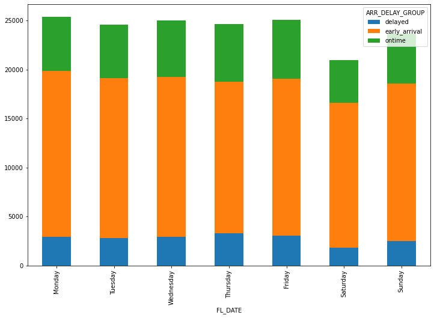

```python
ctd = pd.crosstab(flight_data["FL_DATE"].dt.dayofweek,flight_data['ARR_DELAY_GROUP'])
ctd.plot(kind='bar',stacked=True,figsize = (12,8))
plt.xticks([0,1,2,3,4,5,6],["Monday", "Tuesday", "Wednesday", "Thursday", "Friday", "Saturday", "Sunday"])
plt.show()
```

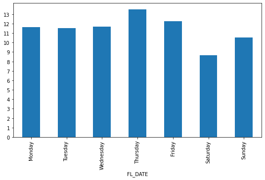

```python
plt.figure(figsize=(9,5))
((ctd['delayed']/(ctd['delayed']+ctd['early_arrival']+ctd['ontime']))*100).plot(kind="bar")

plt.yticks(np.arange(0,14))
plt.xticks([0,1,2,3,4,5,6],["Monday", "Tuesday", "Wednesday", "Thursday", "Friday", "Saturday", "Sunday"])
plt.show()
```

```python
((ctd['delayed']/(ctd['delayed']+ctd['early_arrival']+ctd['ontime']))*100)
```

```
FL_DATE
0    11.628182
1    11.507307
2    11.688779
3    13.497381
4    12.232452
5     8.681978
6    10.538335
dtype: float64
```

From the above we can say that there are some slight more delays on Thursday and Friday. Low delays on Saturday and rest all days delays are nearly same.

let see if there are any delays for a Origin airport more. The tail number is the physical identification number for a flight where as the flight number is a virtual number for a flight going on a specific route.

# 2.5 Origin vs Delay

```python
origin_delay = flight_data.groupby([flight_data.ORIGIN,flight_data.ARR_DELAY_GROUP]).size().unstack()
origin_delay["total"]=(origin_delay['delayed']+origin_delay['early_arrival']+origin_delay['ontime'])
origin_delay["pdelayed"]=(origin_delay['delayed']/origin_delay["total"])*100
origin_delay.describe()
```

| ARR_DELAY_GROUP | delayed | early_arrival | ontime | total | pdelayed |
| --- | --- | --- | --- | --- | --- |
| count | 341.000000 | 371.000000 | 364.000000 | 337.000000 | 337.000000 |
| mean | 56.920821 | 301.285714 | 104.755495 | 501.376855 | 12.182457 |
| std | 146.027726 | 703.889364 | 263.443928 | 1140.941363 | 6.613972 |
| min | 1.000000 | 1.000000 | 1.000000 | 5.000000 | 2.521008 |
| 25% | 3.000000 | 15.000000 | 5.000000 | 27.000000 | 8.333333 |
| 50% | 10.000000 | 56.000000 | 16.000000 | 101.000000 | 11.023622 |
| 75% | 35.000000 | 194.500000 | 66.000000 | 351.000000 | 14.056225 |
| max | 1420.000000 | 5804.000000 | 2197.000000 | 8621.000000 | 60.000000 |

From the above analysis it was found some airports have more delay, so the origin can be a good feature for predicition

## 2.6 Destination vs Delay

```python
origin_delay = flight_data.groupby([flight_data.DEST,flight_data.ARR_DELAY_GROUP]).size().unstack()
origin_delay["total"]=(origin_delay['delayed']+origin_delay['early_arrival']+origin_delay['ontime'])
origin_delay["pdelayed"]=(origin_delay['delayed']/origin_delay["total"])*100
origin_delay.describe()
```

| ARR_DELAY_GROUP | delayed | early_arrival | ontime | total | pdelayed |
| --- | --- | --- | --- | --- | --- |
| count | 341.000000 | 367.000000 | 355.000000 | 330.000000 | 330.000000 |
| mean | 56.920821 | 304.569482 | 107.411268 | 511.712121 | 12.453918 |
| std | 136.440451 | 728.856995 | 251.066673 | 1150.691017 | 5.867711 |
| min | 1.000000 | 1.000000 | 1.000000 | 7.000000 | 2.631579 |
| 25% | 3.000000 | 13.000000 | 6.000000 | 33.000000 | 8.854559 |
| 50% | 11.000000 | 52.000000 | 21.000000 | 103.000000 | 11.599149 |
| 75% | 41.000000 | 197.500000 | 73.000000 | 361.750000 | 14.330811 |
| max | 1227.000000 | 5881.000000 | 1879.000000 | 8553.000000 | 42.857143 |

# 3. Feature Engineering

## 3.1 Removing the features from the train data that are not present in the test data.

```python
features_to_remove = flight_data.columns.difference(test_data.columns)
features_to_remove=list(features_to_remove)
features_to_remove.pop(0)
flight_data1 = flight_data.drop(columns=features_to_remove,axis=1)
test_data1=test_data.drop(columns="UNIQUE_ID",axis=1)
print(flight_data1.columns,test_data.columns)
```

```
Index(['FL_DATE', 'OP_UNIQUE_CARRIER', 'OP_CARRIER', 'TAIL_NUM',
       'OP_CARRIER_FL_NUM', 'ORIGIN_AIRPORT_ID', 'ORIGIN', 'DEST_AIRPORT_ID',
       'DEST', 'CRS_DEP_TIME', 'CRS_ARR_TIME', 'ARR_DELAY_GROUP', 'DISTANCE'],
      dtype='object') Index(['UNIQUE_ID', 'FL_DATE', 'OP_UNIQUE_CARRIER', 'OP_CARRIER', 'TAIL_NUM',
       'OP_CARRIER_FL_NUM', 'ORIGIN_AIRPORT_ID', 'ORIGIN', 'DEST_AIRPORT_ID',
       'DEST', 'CRS_DEP_TIME', 'CRS_ARR_TIME', 'DISTANCE'],
      dtype='object')
```

### 3.2 The features 'OP_UNIQUE_CARRIER' and 'OP_CARRIER' have the same information so removing one out of them.

```python
flight_data1.drop(columns='OP_UNIQUE_CARRIER',axis=1,inplace=True)
test_data1.drop(columns='OP_UNIQUE_CARRIER',axis=1,inplace=True)
```

### 3.3 The features "ORIGIN_AIRPORT_ID" and "ORIGIN" have origin airport id and origin aiport names respectively, so keeping one is enough for training the model. In the same way for the features "DEST_AIRPORT_ID" and "DEST", keeping one among them can solve the purpose.

```python
flight_data1.drop(columns=['ORIGIN_AIRPORT_ID','DEST_AIRPORT_ID'],axis=1,inplace=True)
test_data1.drop(columns=['ORIGIN_AIRPORT_ID','DEST_AIRPORT_ID'],axis=1,inplace=True)
```

## 3.4 Extracting Hour and Minutes from Time feature

```python
flight_data1.CRS_ARR_TIME=flight_data1.CRS_ARR_TIME.astype('str')
test_data1.CRS_ARR_TIME=test_data1.CRS_ARR_TIME.astype('str')
flight_data1.CRS_DEP_TIME=flight_data1.CRS_DEP_TIME.astype('str')
test_data1.CRS_DEP_TIME=test_data1.CRS_DEP_TIME.astype('str')
```

```python
def replacenullwithzero(data,feature):
    for i in range(0,len(data)):
        if(data[feature][i]==''):
            data[feature][i]=0
```

```python
flight_data1["CRS_ARR_TIME_MM"]=flight_data1.CRS_ARR_TIME.str.slice(-2)
flight_data1["CRS_DEP_TIME_MM"]=flight_data1.CRS_DEP_TIME.str.slice(-2)
flight_data1["CRS_ARR_TIME_HR"]=flight_data1.CRS_ARR_TIME.str.slice(-4,-2)
flight_data1["CRS_DEP_TIME_HR"]=flight_data1.CRS_DEP_TIME.str.slice(-4,-2)

test_data1["CRS_ARR_TIME_MM"]=flight_data1.CRS_ARR_TIME.str.slice(-2)
test_data1["CRS_DEP_TIME_MM"]=flight_data1.CRS_DEP_TIME.str.slice(-2)
test_data1["CRS_ARR_TIME_HR"]=flight_data1.CRS_ARR_TIME.str.slice(-4,-2)
test_data1["CRS_DEP_TIME_HR"]=flight_data1.CRS_DEP_TIME.str.slice(-4,-2)


replacenullwithzero(flight_data1,"CRS_ARR_TIME_HR")
replacenullwithzero(test_data1,"CRS_ARR_TIME_HR")
replacenullwithzero(flight_data1,"CRS_DEP_TIME_HR")
replacenullwithzero(test_data1,"CRS_DEP_TIME_HR")
```

### 3.5 Adding new columns based on date

```python
flight_data1.FL_DATE=pd.to_datetime(flight_data["FL_DATE"])
test_data1.FL_DATE=pd.to_datetime(test_data["FL_DATE"])
```

```python
flight_data1["FL_DATE_WEEKDAY"]=flight_data1["FL_DATE"].dt.dayofweek
test_data1["FL_DATE_WEEKDAY"]=test_data1["FL_DATE"].dt.dayofweek
```

```python
flight_data1["FL_DATE_MONTH"]=flight_data1["FL_DATE"].dt.month
test_data1["FL_DATE_MONTH"]=test_data1["FL_DATE"].dt.month
```

```python
flight_data1["FL_DATE_DAY"]=flight_data1["FL_DATE"].dt.day
test_data1["FL_DATE_DAY"]=test_data1["FL_DATE"].dt.day
```

### 3.6 Removing 'CRS_ARR_TIME' and 'CRS_DEP_TIME' from train and test.

```python
flight_data1.drop(columns=['CRS_ARR_TIME' , 'CRS_DEP_TIME',"FL_DATE",],axis=1,inplace=True)
test_data1.drop(columns=['CRS_ARR_TIME' , 'CRS_DEP_TIME',"FL_DATE"],axis=1,inplace=True)
```

```python
flight_data1.head()
```

|  | OP_CARRIER | TAIL_NUM | OP_CARRIER_FL_NUM | ORIGIN | DEST | ARR_DELAY_GROUP | DISTANCE | CRS_ARR_TIME_MM | CRS_DEP_TIME_MM | CRS_ARR_TIME_HR | CRS_DEP_TIME_HR | FL_DATE_WEEKDAY | FL_DATE_MONTH | FL_DATE_DAY |
| --- | --- | --- | --- | --- | --- | --- | --- | --- | --- | --- | --- | --- | --- | --- |
| 0 | ZW | N454AW | 3791 | AZO | ORD | early_arrival | 122.0 | 32 | 26 | 14 | 14 | 1 | 7 | 9 |
| 1 | C5 | N12195 | 4895 | EWR | ROC | ontime | 246.0 | 14 | 55 | 14 | 12 | 3 | 7 | 11 |
| 2 | DL | N841DN | 1926 | ATL | MCI | ontime | 692.0 | 56 | 48 | 22 | 21 | 1 | 7 | 23 |
| 3 | B6 | N981JT | 1078 | LAS | BOS | early_arrival | 2381.0 | 11 | 00 | 15 | 7 | 0 | 7 | 8 |
| 4 | DL | N807DN | 1779 | MSP | DEN | early_arrival | 680.0 | 04 | 51 | 13 | 11 | 6 | 7 | 28 |

```python
test_data1.head()
```

|  | OP_CARRIER | TAIL_NUM | OP_CARRIER_FL_NUM | ORIGIN | DEST | DISTANCE | CRS_ARR_TIME_MM | CRS_DEP_TIME_MM | CRS_ARR_TIME_HR | CRS_DEP_TIME_HR | FL_DATE_WEEKDAY | FL_DATE_MONTH | FL_DATE_DAY |
| --- | --- | --- | --- | --- | --- | --- | --- | --- | --- | --- | --- | --- | --- |
| 0 | 9E | N186PQ | 5387 | LGA | RDU | 431.0 | 32 | 26 | 14 | 14 | 0 | 12 | 16 |
| 1 | AS | N267AK | 660 | SEA | SLC | 689.0 | 14 | 55 | 14 | 12 | 1 | 12 | 3 |
| 2 | B6 | N504JB | 794 | AUS | JFK | 1521.0 | 56 | 48 | 22 | 21 | 0 | 12 | 30 |
| 3 | OH | N599NN | 5456 | CLT | IND | 427.0 | 11 | 00 | 15 | 7 | 3 | 12 | 19 |
| 4 | OO | N964SW | 5342 | RDM | SFO | 462.0 | 04 | 51 | 13 | 11 | 2 | 12 | 4 |

# Encoding the time based cyclic features with sin and cos transformations

```python
flight_data1["CRS_ARR_MIN"]=(flight_data1["CRS_ARR_TIME_MM"]).astype(int)+flight_data1["CRS_ARR_TIME_HR"].astype(int)*60
flight_data1["CRS_DEP_MIN"]=flight_data1["CRS_DEP_TIME_MM"].astype(int)+flight_data1["CRS_DEP_TIME_HR"].astype(int)*60
min_in_day = 24*60
flight_data1["CRS_ARR_MIN_SIN"]=np.sin(2*np.pi*flight_data1["CRS_ARR_MIN"]/min_in_day)
flight_data1["CRS_ARR_MIN_COS"]=np.cos(2*np.pi*flight_data1["CRS_ARR_MIN"]/min_in_day)
flight_data1["CRS_DEP_MIN_SIN"]=np.sin(2*np.pi*flight_data1["CRS_DEP_MIN"]/min_in_day)
flight_data1["CRS_DEP_MIN_COS"]=np.cos(2*np.pi*flight_data1["CRS_DEP_MIN"]/min_in_day)
```

```python
flight_data1.head()
```

|  | OP_CARRIER | TAIL_NUM | OP_CARRIER_FL_NUM | ORIGIN | DEST | ARR_DELAY_GROUP | DISTANCE | CRS_ARR_TIME_MM | CRS_DEP_TIME_MM | CRS_ARR_TIME_HR | CRS_DEP_TIME_HR | FL_DATE_WEEKDAY | FL_DATE_MONTH | FL_DATE_DAY | CRS_ARR_MIN | CRS_DEP_MIN | CRS_ARR_MIN_SIN | CRS_ARR_MIN_COS | CRS_DEP_MIN_SIN | CRS_DEP_MIN_COS |
| --- | --- | --- | --- | --- | --- | --- | --- | --- | --- | --- | --- | --- | --- | --- | --- | --- | --- | --- | --- | --- |
| 0 | ZW | N454AW | 3791 | AZO | ORD | early_arrival | 122.0 | 32 | 26 | 14 | 14 | 1 | 7 | 9 | 872 | 866 | -0.615661 | -0.788011 | -0.594823 | -0.803857 |
| 1 | C5 | N12195 | 4895 | EWR | ROC | ontime | 246.0 | 14 | 55 | 14 | 12 | 3 | 7 | 11 | 854 | 775 | -0.551937 | -0.833886 | -0.237686 | -0.971342 |
| 2 | DL | N841DN | 1926 | ATL | MCI | ontime | 692.0 | 56 | 48 | 22 | 21 | 1 | 7 | 23 | 1376 | 1308 | -0.275637 | 0.961262 | -0.544639 | 0.838671 |
| 3 | B6 | N981JT | 1078 | LAS | BOS | early_arrival | 2381.0 | 11 | 00 | 15 | 7 | 0 | 7 | 8 | 911 | 420 | -0.740218 | -0.672367 | 0.965926 | -0.258819 |
| 4 | DL | N807DN | 1779 | MSP | DEN | early_arrival | 680.0 | 04 | 51 | 13 | 11 | 6 | 7 | 28 | 784 | 711 | -0.275637 | -0.961262 | 0.039260 | -0.999229 |

```python
test_data1["CRS_ARR_MIN"]=(test_data1["CRS_ARR_TIME_MM"]).astype(int)+test_data1["CRS_ARR_TIME_HR"].astype(int)*60
test_data1["CRS_DEP_MIN"]=test_data1["CRS_DEP_TIME_MM"].astype(int)+test_data1["CRS_DEP_TIME_HR"].astype(int)*60
min_in_day = 24*60
test_data1["CRS_ARR_MIN_SIN"]=np.sin(2*np.pi*test_data1["CRS_ARR_MIN"]/min_in_day)
test_data1["CRS_ARR_MIN_COS"]=np.cos(2*np.pi*test_data1["CRS_ARR_MIN"]/min_in_day)
test_data1["CRS_DEP_MIN_SIN"]=np.sin(2*np.pi*test_data1["CRS_DEP_MIN"]/min_in_day)
test_data1["CRS_DEP_MIN_COS"]=np.cos(2*np.pi*test_data1["CRS_DEP_MIN"]/min_in_day)
```

```python
flight_data1["FL_DATE_WEEKDAY_SIN"]=np.sin(2*np.pi*flight_data1["FL_DATE_WEEKDAY"]/7)
flight_data1["FL_DATE_WEEKDAY_COS"]=np.cos(2*np.pi*flight_data1["FL_DATE_WEEKDAY"]/7)

test_data1["FL_DATE_WEEKDAY_SIN"]=np.sin(2*np.pi*test_data1["FL_DATE_WEEKDAY"]/7)
test_data1["FL_DATE_WEEKDAY_COS"]=np.cos(2*np.pi*test_data1["FL_DATE_WEEKDAY"]/7)
```

```python
flight_data1["FL_DATE_MONTH_SIN"]=np.sin(2*np.pi*flight_data1["FL_DATE_MONTH"]/12)
flight_data1["FL_DATE_MONTH_COS"]=np.cos(2*np.pi*flight_data1["FL_DATE_MONTH"]/12)

test_data1["FL_DATE_MONTH_SIN"]=np.sin(2*np.pi*test_data1["FL_DATE_MONTH"]/12)
test_data1["FL_DATE_MONTH_COS"]=np.cos(2*np.pi*test_data1["FL_DATE_MONTH"]/12)
```

```python
days_in_month = [31, 28, 31, 30, 31, 30, 31, 31, 30, 31, 30, 31]

for i in range(0,len(flight_data1)):
    month=flight_data1["FL_DATE_MONTH"][i]-1
    flight_data1["FL_DATE_DAY_SIN"][i]=np.sin(2*np.pi*flight_data1["FL_DATE_DAY"][i]/days_in_month[month])
    flight_data1["FL_DATE_DAY_COS"][i]=np.cos(2*np.pi*flight_data1["FL_DATE_DAY"][i]/days_in_month[month])
```

```python
days_in_month = [31, 28, 31, 30, 31, 30, 31, 31, 30, 31, 30, 31]

for i in range(0,len(test_data1)):
    month_test = test_data1["FL_DATE_MONTH"][i]-1
    test_data1["FL_DATE_DAY_SIN"][i]=np.sin(2*np.pi*test_data1["FL_DATE_DAY"][i]/days_in_month[month_test])
    test_data1["FL_DATE_DAY_COS"][i]=np.cos(2*np.pi*test_data1["FL_DATE_DAY"][i]/days_in_month[month_test])
```

```python
flight_data1.head()
```

[output not shown]

```python
test_data1.head()
```

[output not shown]

```python
flight_data1.FL_DATE_DAY_COS.value_counts()
```

```
 0    164501
 1      5380
-1      2313
Name: FL_DATE_DAY_COS, dtype: int64
```

## 3.7 Removing the extra features that have already been replaced

```python
flight_data2=flight_data1.drop(columns=['CRS_ARR_TIME_MM', 'CRS_DEP_TIME_MM',
       'CRS_ARR_TIME_HR', 'CRS_DEP_TIME_HR', 'FL_DATE_WEEKDAY',
       'FL_DATE_MONTH', 'FL_DATE_DAY'],axis=1)
test_data2=test_data1.drop(columns=['CRS_ARR_TIME_MM', 'CRS_DEP_TIME_MM',
       'CRS_ARR_TIME_HR', 'CRS_DEP_TIME_HR', 'FL_DATE_WEEKDAY',
       'FL_DATE_MONTH', 'FL_DATE_DAY', ],axis=1)
```

# 4. Type casting the features

```python
flight_data2.dtypes
```

```
OP_CARRIER              object
TAIL_NUM                object
OP_CARRIER_FL_NUM        int64
ORIGIN                  object
DEST                    object
ARR_DELAY_GROUP         object
DISTANCE               float64
CRS_ARR_MIN_SIN        float64
CRS_ARR_MIN_COS        float64
CRS_DEP_MIN_SIN        float64
CRS_DEP_MIN_COS        float64
FL_DATE_WEEKDAY_SIN    float64
FL_DATE_WEEKDAY_COS    float64
FL_DATE_MONTH_SIN      float64
FL_DATE_MONTH_COS      float64
FL_DATE_DAY_SIN        float64
FL_DATE_DAY_COS        float64
dtype: object
```

### 4.1 Converting the features to category

```python
cat_cols = ["OP_CARRIER","TAIL_NUM","OP_CARRIER_FL_NUM","ORIGIN","DEST","ARR_DELAY_GROUP"]
def typecastcat(data):

    for i in range(0,len(data.columns)):
        j=data.columns[i]
        if(j in cat_cols):
            data[j]=data[j].astype('category')
```

```python
typecastcat(flight_data2)
typecastcat(test_data2)
```

### 4.2 Converting Numerical features to int

```python
num_cols = ["DISTANCE"]
def typecastnum(data):
    for i in range(0,len(data.columns)):
            j=data.columns[i]
            if(j in num_cols):
                data[j]=data[j].astype("int")
```

```python
typecastnum(flight_data2)
typecastnum(test_data2)
```

```python
test_data2.dtypes
```

```
OP_CARRIER             category
TAIL_NUM               category
OP_CARRIER_FL_NUM      category
ORIGIN                 category
DEST                   category
DISTANCE                  int32
CRS_ARR_MIN_SIN         float64
CRS_ARR_MIN_COS         float64
CRS_DEP_MIN_SIN         float64
CRS_DEP_MIN_COS         float64
FL_DATE_WEEKDAY_SIN     float64
FL_DATE_WEEKDAY_COS     float64
FL_DATE_MONTH_SIN       float64
FL_DATE_MONTH_COS       float64
FL_DATE_DAY_SIN         float64
FL_DATE_DAY_COS         float64
dtype: object
```

```python
flight_data2.dtypes
```

```
OP_CARRIER             category
TAIL_NUM               category
OP_CARRIER_FL_NUM      category
ORIGIN                 category
DEST                   category
ARR_DELAY_GROUP        category
DISTANCE                  int32
CRS_ARR_MIN_SIN         float64
CRS_ARR_MIN_COS         float64
CRS_DEP_MIN_SIN         float64
CRS_DEP_MIN_COS         float64
FL_DATE_WEEKDAY_SIN     float64
FL_DATE_WEEKDAY_COS     float64
FL_DATE_MONTH_SIN       float64
FL_DATE_MONTH_COS       float64
FL_DATE_DAY_SIN         float64
FL_DATE_DAY_COS         float64
dtype: object
```

### 5. Handling Missing values

#### 5.1 Checking for NULL values in the dataset

```python
flight_data2.isnull().sum()
```

```
OP_CARRIER                0
TAIL_NUM                427
OP_CARRIER_FL_NUM         0
ORIGIN                    0
DEST                      0
ARR_DELAY_GROUP        2876
DISTANCE                  0
CRS_ARR_MIN_SIN           0
CRS_ARR_MIN_COS           0
CRS_DEP_MIN_SIN           0
CRS_DEP_MIN_COS           0
FL_DATE_WEEKDAY_SIN       0
FL_DATE_WEEKDAY_COS       0
FL_DATE_MONTH_SIN         0
FL_DATE_MONTH_COS         0
FL_DATE_DAY_SIN           0
FL_DATE_DAY_COS           0
dtype: int64
```

##### The target variable contains null values, so it is better to remove the null target rows from the train data

```python
flight_data2.dropna(axis=0,inplace=True)
flight_data2.isnull().sum()
```

```
OP_CARRIER             0
TAIL_NUM               0
OP_CARRIER_FL_NUM      0
ORIGIN                 0
DEST                   0
ARR_DELAY_GROUP        0
DISTANCE               0
CRS_ARR_MIN_SIN        0
CRS_ARR_MIN_COS        0
CRS_DEP_MIN_SIN        0
CRS_DEP_MIN_COS        0
FL_DATE_WEEKDAY_SIN    0
FL_DATE_WEEKDAY_COS    0
FL_DATE_MONTH_SIN      0
FL_DATE_MONTH_COS      0
FL_DATE_DAY_SIN        0
FL_DATE_DAY_COS        0
dtype: int64
```

```python
test_data2.isnull().sum()
```

```
OP_CARRIER             0
TAIL_NUM               0
OP_CARRIER_FL_NUM      0
ORIGIN                 0
DEST                   0
DISTANCE               0
CRS_ARR_MIN_SIN        0
CRS_ARR_MIN_COS        0
CRS_DEP_MIN_SIN        0
CRS_DEP_MIN_COS        0
FL_DATE_WEEKDAY_SIN    0
FL_DATE_WEEKDAY_COS    0
FL_DATE_MONTH_SIN      0
FL_DATE_MONTH_COS      0
FL_DATE_DAY_SIN        0
FL_DATE_DAY_COS        0
dtype: int64
```

```python
print(test_data2.shape,flight_data2.shape)
```

```
(33581, 16) (169318, 17)
```

### 6. Standardization

```python
from sklearn.preprocessing import StandardScaler
scaler = StandardScaler()
distance = pd.DataFrame(flight_data2["DISTANCE"])
flight_data2["DISTANCE"]=scaler.fit_transform(distance)
distance_t = pd.DataFrame(test_data1["DISTANCE"])
test_data2["DISTANCE"]=scaler.fit_transform(distance_t)
```

```python
test_data2.DISTANCE
```

```
0       -0.600185
1       -0.161871
2        1.251606
3       -0.606980
4       -0.547519
           ...
33576   -0.654549
33577   -0.328362
33578   -0.668140
33579   -0.795557
33580   -0.751386
Name: DISTANCE, Length: 33581, dtype: float64
```

```python
test_data2.shape
```

```
(33581, 16)
```

### 7. Encoding the categorical values

```python
flight_data2.dtypes
```

```
OP_CARRIER             category
TAIL_NUM               category
OP_CARRIER_FL_NUM      category
ORIGIN                 category
DEST                   category
ARR_DELAY_GROUP        category
DISTANCE                float64
CRS_ARR_MIN_SIN         float64
CRS_ARR_MIN_COS         float64
CRS_DEP_MIN_SIN         float64
CRS_DEP_MIN_COS         float64
FL_DATE_WEEKDAY_SIN     float64
FL_DATE_WEEKDAY_COS     float64
FL_DATE_MONTH_SIN       float64
FL_DATE_MONTH_COS       float64
FL_DATE_DAY_SIN           int32
FL_DATE_DAY_COS           int32
dtype: object
```

```python
flight_data2.ARR_DELAY_GROUP.replace({"early_arrival":-1,"ontime":0,"delayed":1},inplace=True)
flight_data2.ARR_DELAY_GROUP=flight_data2.ARR_DELAY_GROUP.astype('int')
```

```python
!pip install category_encoders
```

```python
import category_encoders as ce
```

```python
encode= ce.TargetEncoder()
encode.fit(flight_data2.drop(columns="ARR_DELAY_GROUP"),flight_data2["ARR_DELAY_GROUP"])
```

```
TargetEncoder(cols=['OP_CARRIER', 'TAIL_NUM', 'OP_CARRIER_FL_NUM', 'ORIGIN',
                    'DEST'],
              drop_invariant=False, handle_missing='value',
              handle_unknown='value', min_samples_leaf=1, return_df=True,
              smoothing=1.0, verbose=0)
```

```python
flight_data3 =encode.transform(flight_data2.drop(columns="ARR_DELAY_GROUP"))
test_data3 = encode.transform(test_data2)
```

```python
test_data3.head()
```

|  | OP_CARRIER | TAIL_NUM | OP_CARRIER_FL_NUM | ORIGIN | DEST | DISTANCE | CRS_ARR_MIN_SIN | CRS_ARR_MIN_COS | CRS_DEP_MIN_SIN | CRS_DEP_MIN_COS | FL_DATE_WEEKDAY_SIN | FL_DATE_WEEKDAY_COS | FL_DATE_MONTH_SIN | FL_DATE_MONTH_COS | FL_DATE_DAY_SIN | FL_DATE_DAY_COS |
| --- | --- | --- | --- | --- | --- | --- | --- | --- | --- | --- | --- | --- | --- | --- | --- | --- |
| 0 | -0.632019 | -0.655172 | -0.347826 | -0.461166 | -0.542000 | -0.600185 | -0.615661 | -0.788011 | -0.594823 | -0.803857 | 0.000000 | 1.000000 | -2.449294e-16 | 1.0 | -0.101168 | -0.994869 |
| 1 | -0.560691 | -0.629630 | -0.500000 | -0.545969 | -0.601172 | -0.161871 | -0.551937 | -0.833886 | -0.237686 | -0.971342 | 0.781831 | 0.623490 | -2.449294e-16 | 1.0 | 0.571268 | 0.820763 |
| 2 | -0.465464 | -0.416667 | -0.464286 | -0.586037 | -0.530350 | 1.251606 | -0.275637 | 0.961262 | -0.544639 | 0.838671 | 0.000000 | 1.000000 | -2.449294e-16 | 1.0 | -0.201299 | 0.979530 |
| 3 | -0.508790 | -0.500000 | -0.444478 | -0.490321 | -0.551942 | -0.606980 | -0.740218 | -0.672367 | 0.965926 | -0.258819 | 0.433884 | -0.900969 | -2.449294e-16 | 1.0 | -0.651372 | -0.758758 |
| 4 | -0.570067 | -0.320755 | -0.708333 | -0.494565 | -0.497568 | -0.547519 | -0.275637 | -0.961262 | 0.039260 | -0.999229 | 0.974928 | -0.222521 | -2.449294e-16 | 1.0 | 0.724793 | 0.688967 |

```python
flight_data3.head()
```

|  | OP_CARRIER | TAIL_NUM | OP_CARRIER_FL_NUM | ORIGIN | DEST | DISTANCE | CRS_ARR_MIN_SIN | CRS_ARR_MIN_COS | CRS_DEP_MIN_SIN | CRS_DEP_MIN_COS | FL_DATE_WEEKDAY_SIN | FL_DATE_WEEKDAY_COS | FL_DATE_MONTH_SIN | FL_DATE_MONTH_COS | FL_DATE_DAY_SIN | FL_DATE_DAY_COS |
| --- | --- | --- | --- | --- | --- | --- | --- | --- | --- | --- | --- | --- | --- | --- | --- | --- |
| 0 | -0.525690 | -0.558824 | -0.454545 | -0.546512 | -0.493394 | -1.100328 | -0.615661 | -0.788011 | -0.594823 | -0.803857 | 0.781831 | 0.623490 | -0.5 | -0.866025 | 0.968077 | -0.250653 |
| 1 | -0.286161 | -0.260870 | -0.533333 | -0.355287 | -0.503546 | -0.889004 | -0.551937 | -0.833886 | -0.237686 | -0.971342 | 0.433884 | -0.900969 | -0.5 | -0.866025 | 0.790776 | -0.612106 |
| 2 | -0.616983 | -0.750000 | -0.619048 | -0.615059 | -0.551515 | -0.128919 | -0.275637 | 0.961262 | -0.544639 | 0.838671 | 0.781831 | 0.623490 | -0.5 | -0.866025 | -0.998717 | -0.050649 |
| 3 | -0.465464 | -0.785714 | -0.659574 | -0.563310 | -0.493827 | 2.749518 | -0.740218 | -0.672367 | 0.965926 | -0.258819 | 0.000000 | 1.000000 | -0.5 | -0.866025 | 0.998717 | -0.050649 |
| 4 | -0.616983 | -0.703704 | -0.500000 | -0.623954 | -0.500243 | -0.149370 | -0.275637 | -0.961262 | 0.039260 | -0.999229 | -0.781831 | 0.623490 | -0.5 | -0.866025 | -0.571268 | 0.820763 |

### 8. Train-Validation Split

```python
X_train,X_val,y_train,y_val = train_test_split(flight_data3,flight_data2["ARR_DELAY_GROUP"],test_size=0.3,random_state=20)
```

```python
y_train.value_counts(normalize=True)*100
```

```
-1    66.064528
 0    22.477683
 1    11.457788
Name: ARR_DELAY_GROUP, dtype: float64
```

```python
y_val.value_counts(normalize=True)*100
```

```
-1    65.902827
 0    22.619891
 1    11.477282
Name: ARR_DELAY_GROUP, dtype: float64
```

```python
X_train.head()
```

|  | OP_CARRIER | TAIL_NUM | OP_CARRIER_FL_NUM | ORIGIN | DEST | DISTANCE | CRS_ARR_MIN_SIN | CRS_ARR_MIN_COS | CRS_DEP_MIN_SIN | CRS_DEP_MIN_COS | FL_DATE_WEEKDAY_SIN | FL_DATE_WEEKDAY_COS | FL_DATE_MONTH_SIN | FL_DATE_MONTH_COS | FL_DATE_DAY_SIN | FL_DATE_DAY_COS |
| --- | --- | --- | --- | --- | --- | --- | --- | --- | --- | --- | --- | --- | --- | --- | --- | --- |
| 76386 | -0.502658 | -0.464286 | -0.333333 | -0.742138 | -0.500243 | 0.252828 | 0.442289 | -0.896873 | 0.977231 | -0.212178 | 0.781831 | 0.623490 | -1.000000 | -1.836970e-16 | -0.951057 | 0.309017 |
| 100499 | -0.465464 | -0.666667 | -0.642857 | -0.474074 | -0.530350 | 1.415109 | -0.374607 | -0.927184 | 0.605294 | -0.796002 | 0.000000 | 1.000000 | -1.000000 | -1.836970e-16 | 0.951057 | -0.309017 |
| 5586 | -0.587078 | -0.652174 | -0.722222 | -0.611415 | -0.648456 | -0.619736 | -0.691513 | -0.722364 | -0.362438 | -0.932008 | 0.000000 | 1.000000 | -0.500000 | -8.660254e-01 | -0.968077 | -0.250653 |
| 56138 | -0.570067 | -0.618182 | -0.565217 | -0.636364 | -0.582566 | -0.650412 | 0.850352 | -0.526214 | 0.990268 | -0.139173 | -0.433884 | -0.900969 | -0.866025 | -5.000000e-01 | 0.394356 | 0.918958 |
| 118868 | -0.616983 | -0.708333 | -0.704545 | -0.579206 | -0.608269 | -0.611215 | -0.608761 | 0.793353 | -0.872496 | 0.488621 | 0.781831 | 0.623490 | -0.866025 | 5.000000e-01 | 0.201299 | 0.979530 |

## 9. Handling class-imbalnce

```python
# over sampling
from imblearn.over_sampling import RandomOverSampler
ros = RandomOverSampler()
X_ros, y_ros = ros.fit_sample(X_train, y_train)
```

[output not shown]

```python
#Undersampling
from imblearn.under_sampling import RandomUnderSampler
rus = RandomUnderSampler()
X_rus,y_rus=rus.fit_sample(X_train, y_train)
```

# 10. Model Building

```python
from sklearn.metrics import accuracy_score,recall_score,precision_score,f1_score


scores = pd.DataFrame(columns=['Model','Train_Accuracy','Train_Recall','Train_Precision','Train_F1_Score','Val_Accuracy','Val_Recall','Val_Precision','Val_F1_Score'])

def get_metrics(train_actual,train_predicted,val_actual,val_predicted,model_description,dataframe):
    train_accuracy = accuracy_score(train_actual,train_predicted)
    train_recall   = recall_score(train_actual,train_predicted,average="micro")
    train_precision= precision_score(train_actual,train_predicted,average="micro")
    train_f1score  = f1_score(train_actual,train_predicted,average="micro")
    val_accuracy = accuracy_score(val_actual,val_predicted)
    val_recall   = recall_score(val_actual,val_predicted,average="micro")
    val_precision= precision_score(val_actual,val_predicted,average="micro")
    val_f1score  = f1_score(val_actual,val_predicted,average="micro")
    dataframe = dataframe.append(pd.Series([model_description, train_accuracy,train_recall,train_precision,train_f1score,
                                            val_accuracy,val_recall,val_precision,val_f1score],
                                           index=scores.columns ), ignore_index=True)
    return(dataframe)
```

## 10.1 Building Decision Trees

```python
from sklearn.tree import DecisionTreeClassifier

dtc=DecisionTreeClassifier()
dtc.fit(X_train,y_train)
```

```
DecisionTreeClassifier(ccp_alpha=0.0, class_weight=None, criterion='gini',
                       max_depth=None, max_features=None, max_leaf_nodes=None,
                       min_impurity_decrease=0.0, min_impurity_split=None,
                       min_samples_leaf=1, min_samples_split=2,
                       min_weight_fraction_leaf=0.0, presort='deprecated',
                       random_state=None, splitter='best')
```

```python
train_pred = dtc.predict(X_train)
val_pred = dtc.predict(X_val)
```

```python
dt_train = classification_report(y_pred=train_pred,y_true=y_train)
print(dt_train)
```

```
              precision    recall  f1-score   support

          -1       1.00      1.00      1.00     78301
           0       1.00      1.00      1.00     26641
           1       1.00      1.00      1.00     13580

    accuracy                           1.00    118522
   macro avg       1.00      1.00      1.00    118522
weighted avg       1.00      1.00      1.00    118522
```

```python
dt_val = classification_report(y_pred=val_pred,y_true=y_val)
print(dt_val)
```

```
              precision    recall  f1-score   support

          -1       0.70      0.68      0.69     33476
           0       0.25      0.26      0.26     11490
           1       0.20      0.22      0.21      5830

    accuracy                           0.53     50796
   macro avg       0.38      0.39      0.39     50796
weighted avg       0.54      0.53      0.54     50796
```

```python
scores=get_metrics(y_train,train_pred,y_val,val_pred,"DecisionTreePlane",scores)
scores
```

|  | Model | Train_Accuracy | Train_Recall | Train_Precision | Train_F1_Score | Val_Accuracy | Val_Recall | Val_Precision | Val_F1_Score |
| --- | --- | --- | --- | --- | --- | --- | --- | --- | --- |
| 0 | DecisionTreePlane | 1.0 | 1.0 | 1.0 | 1.0 | 0.532818 | 0.532818 | 0.532818 | 0.532818 |
| 1 | DecisionTreePlane | 1.0 | 1.0 | 1.0 | 1.0 | 0.532818 | 0.532818 | 0.532818 | 0.532818 |

# Tuning the hyper parameters with Grid Search

```python
dt_param_grid = {'criterion': ['entropy', 'gini'], 'max_depth': [6,8,10,12],
                 "min_samples_split": [2, 10, 20],"min_samples_leaf": [1, 5, 10],}
dt_paramtuned = GridSearchCV(DecisionTreeClassifier(), param_grid=dt_param_grid, cv=5)
dt_paramtuned.fit(X_train,y_train)
```

```
GridSearchCV(cv=5, error_score=nan,
             estimator=DecisionTreeClassifier(ccp_alpha=0.0, class_weight=None,
                                              criterion='gini', max_depth=None,
                                              max_features=None,
                                              max_leaf_nodes=None,
                                              min_impurity_decrease=0.0,
                                              min_impurity_split=None,
                                              min_samples_leaf=1,
                                              min_samples_split=2,
                                              min_weight_fraction_leaf=0.0,
                                              presort='deprecated',
                                              random_state=None,
                                              splitter='best'),
             iid='deprecated', n_jobs=None,
             param_grid={'criterion': ['entropy', 'gini'],
                         'max_depth': [6, 8, 10, 12],
                         'min_samples_leaf': [1, 5, 10],
                         'min_samples_split': [2, 10, 20]},
             pre_dispatch='2*n_jobs', refit=True, return_train_score=False,
             scoring=None, verbose=0)
```

```python
dt_paramtuned.best_params_
```

```
{'criterion': 'entropy',
 'max_depth': 6,
 'min_samples_leaf': 1,
 'min_samples_split': 2}
```

```python
dt_param_grid = {'criterion': ['gini'], 'max_depth': [2,6,8],
                 "min_samples_split": [1,2,4],"min_samples_leaf": [ 15,20,22,25],"class_weight":['balanced']}
dt_paramtuned1 = GridSearchCV(DecisionTreeClassifier(), param_grid=dt_param_grid, cv=5)
dt_paramtuned1.fit(X_train,y_train)
```

```
GridSearchCV(cv=5, error_score=nan,
             estimator=DecisionTreeClassifier(ccp_alpha=0.0, class_weight=None,
                                              criterion='gini', max_depth=None,
                                              max_features=None,
                                              max_leaf_nodes=None,
                                              min_impurity_decrease=0.0,
                                              min_impurity_split=None,
                                              min_samples_leaf=1,
                                              min_samples_split=2,
                                              min_weight_fraction_leaf=0.0,
                                              presort='deprecated',
                                              random_state=None,
                                              splitter='best'),
             iid='deprecated', n_jobs=None,
             param_grid={'class_weight': ['balanced'], 'criterion': ['gini'],
                         'max_depth': [2, 6, 8],
                         'min_samples_leaf': [15, 20, 22, 25],
                         'min_samples_split': [1, 2, 4]},
             pre_dispatch='2*n_jobs', refit=True, return_train_score=False,
             scoring=None, verbose=0)
```

```python
dt_paramtuned1.best_params_
```

```
{'class_weight': 'balanced',
 'criterion': 'gini',
 'max_depth': 2,
 'min_samples_leaf': 15,
 'min_samples_split': 2}
```

```python
train_pred=dt_paramtuned1.predict(X_train)
val_pred=dt_paramtuned1.predict(X_val)
cr=classification_report(y_val,val_pred)
print(cr)
```

```
              precision    recall  f1-score   support

          -1       0.71      0.79      0.75     33476
           0       0.00      0.00      0.00     11490
           1       0.21      0.51      0.30      5830

    accuracy                           0.58     50796
   macro avg       0.31      0.43      0.35     50796
weighted avg       0.50      0.58      0.53     50796
```

```python
scores=get_metrics(y_train,train_pred,y_val,val_pred,"DecisionTreeTuned",scores)
scores
```

|  | Model | Train_Accuracy | Train_Recall | Train_Precision | Train_F1_Score | Val_Accuracy | Val_Recall | Val_Precision | Val_F1_Score |
| --- | --- | --- | --- | --- | --- | --- | --- | --- | --- |
| 0 | DecisionTreePlane | 1.000000 | 1.000000 | 1.000000 | 1.000000 | 0.532818 | 0.532818 | 0.532818 | 0.532818 |
| 1 | DecisionTreePlane | 1.000000 | 1.000000 | 1.000000 | 1.000000 | 0.532818 | 0.532818 | 0.532818 | 0.532818 |
| 2 | DecisionTreeTuned | 0.581369 | 0.581369 | 0.581369 | 0.581369 | 0.578372 | 0.578372 | 0.578372 | 0.578372 |

# 10.2 Building AdaBoost

```python
from sklearn.linear_model import LogisticRegression
from sklearn.ensemble import AdaBoostClassifier
clf = AdaBoostClassifier(n_estimators=50, learning_rate=0.3,random_state = 0)
```

```python
clf.fit(X = X_train, y = y_train)
```

```
AdaBoostClassifier(algorithm='SAMME.R', base_estimator=None, learning_rate=0.3,
                   n_estimators=50, random_state=0)
```

```python
train_pred=clf.predict(X_train)
val_pred=clf.predict(X_val)
cr=classification_report(y_val,val_pred)
print(cr)
```

```
              precision    recall  f1-score   support

          -1       0.67      0.99      0.80     33476
           0       0.00      0.00      0.00     11490
           1       0.50      0.07      0.12      5830

    accuracy                           0.66     50796
   macro avg       0.39      0.35      0.31     50796
weighted avg       0.50      0.66      0.54     50796
```

```python
scores=get_metrics(y_train,train_pred,y_val,val_pred,"Adaboost",scores)
scores
```

|  | Model | Train_Accuracy | Train_Recall | Train_Precision | Train_F1_Score | Val_Accuracy | Val_Recall | Val_Precision | Val_F1_Score |
| --- | --- | --- | --- | --- | --- | --- | --- | --- | --- |
| 0 | DecisionTreePlane | 1.000000 | 1.000000 | 1.000000 | 1.000000 | 0.532818 | 0.532818 | 0.532818 | 0.532818 |
| 1 | DecisionTreePlane | 1.000000 | 1.000000 | 1.000000 | 1.000000 | 0.532818 | 0.532818 | 0.532818 | 0.532818 |
| 2 | DecisionTreeTuned | 0.581369 | 0.581369 | 0.581369 | 0.581369 | 0.578372 | 0.578372 | 0.578372 | 0.578372 |
| 3 | Adaboost | 0.664130 | 0.664130 | 0.664130 | 0.664130 | 0.663143 | 0.663143 | 0.663143 | 0.663143 |

```python
test_pred_ab=pd.DataFrame(clf.predict(test_data3),columns=["ARR_DELAY_GROUP"])
```

```python
test_pred_ab["UNIQUE_ID"]=test_data["UNIQUE_ID"]
test_pred_ab=test_pred_ab[["UNIQUE_ID","ARR_DELAY_GROUP"]]
```

```python
test_pred_ab.to_csv("Cute_3592(2).csv",index=False)
```

# Tuning the hyper parameter for Adaboost with Grid search

```python
ab_param_grid = { "n_estimators":[75,100], "learning_rate":[0.5,0.7],}
ab_paramtuned = GridSearchCV(AdaBoostClassifier(), param_grid=ab_param_grid, cv=5)
ab_paramtuned.fit(X_train,y_train)
```

```
GridSearchCV(cv=5, error_score=nan,
             estimator=AdaBoostClassifier(algorithm='SAMME.R',
                                          base_estimator=None,
                                          learning_rate=1.0, n_estimators=50,
                                          random_state=None),
             iid='deprecated', n_jobs=None,
             param_grid={'learning_rate': [0.5, 0.7],
                         'n_estimators': [75, 100]},
             pre_dispatch='2*n_jobs', refit=True, return_train_score=False,
             scoring=None, verbose=0)
```

```python
ab_paramtuned.best_params_
```

```
{'learning_rate': 0.7, 'n_estimators': 100}
```

```python
train_pred_ab=ab_paramtuned.predict(X_train)
val_pred_ab=ab_paramtuned.predict(X_val)
```

```python
scores=get_metrics(y_train,train_pred,y_val,val_pred,"Adaboost_param",scores)
scores
```

|  | Model | Train_Accuracy | Train_Recall | Train_Precision | Train_F1_Score | Val_Accuracy | Val_Recall | Val_Precision | Val_F1_Score |
| --- | --- | --- | --- | --- | --- | --- | --- | --- | --- |
| 0 | DecisionTreePlane | 1.000000 | 1.000000 | 1.000000 | 1.000000 | 0.532818 | 0.532818 | 0.532818 | 0.532818 |
| 1 | DecisionTreePlane | 1.000000 | 1.000000 | 1.000000 | 1.000000 | 0.532818 | 0.532818 | 0.532818 | 0.532818 |
| 2 | DecisionTreeTuned | 0.581369 | 0.581369 | 0.581369 | 0.581369 | 0.578372 | 0.578372 | 0.578372 | 0.578372 |
| 3 | Adaboost | 0.664130 | 0.664130 | 0.664130 | 0.664130 | 0.663143 | 0.663143 | 0.663143 | 0.663143 |
| 4 | Adaboost_param | 0.664130 | 0.664130 | 0.664130 | 0.664130 | 0.663143 | 0.663143 | 0.663143 | 0.663143 |

### Adaboost on class balanced data

```python
#AdaBoostClassifier on over sampled data
from sklearn.linear_model import LogisticRegression
from sklearn.ensemble import AdaBoostClassifier
clf_os = AdaBoostClassifier(n_estimators=50, learning_rate=0.3,random_state = 0)
clf_os.fit(X_ros, y_ros)
```

```
AdaBoostClassifier(algorithm='SAMME.R', base_estimator=None, learning_rate=0.3,
                   n_estimators=50, random_state=0)
```

```python
train_pred_os = clf_os.predict(X_train)
val_pred_os = clf_os.predict(X_val)
```

```python
scores=get_metrics(y_train,train_pred_os,y_val,val_pred_os,"Adaboost_OS",scores)
scores
```

|  | Model | Train_Accuracy | Train_Recall | Train_Precision | Train_F1_Score | Val_Accuracy | Val_Recall | Val_Precision | Val_F1_Score |
| --- | --- | --- | --- | --- | --- | --- | --- | --- | --- |
| 0 | DecisionTreePlane | 1.000000 | 1.000000 | 1.000000 | 1.000000 | 0.532818 | 0.532818 | 0.532818 | 0.532818 |
| 1 | DecisionTreePlane | 1.000000 | 1.000000 | 1.000000 | 1.000000 | 0.532818 | 0.532818 | 0.532818 | 0.532818 |
| 2 | DecisionTreeTuned | 0.581369 | 0.581369 | 0.581369 | 0.581369 | 0.578372 | 0.578372 | 0.578372 | 0.578372 |
| 3 | Adaboost | 0.664130 | 0.664130 | 0.664130 | 0.664130 | 0.663143 | 0.663143 | 0.663143 | 0.663143 |
| 4 | Adaboost_param | 0.664130 | 0.664130 | 0.664130 | 0.664130 | 0.663143 | 0.663143 | 0.663143 | 0.663143 |
| 5 | Adaboost_OS | 0.502852 | 0.502852 | 0.502852 | 0.502852 | 0.498386 | 0.498386 | 0.498386 | 0.498386 |

```python
#AdaBoostClassifier on under sampled data
from sklearn.ensemble import AdaBoostClassifier
clf_rus = AdaBoostClassifier(n_estimators=50, learning_rate=0.3,random_state = 0)
clf_rus.fit(X_rus,y_rus)
```

```
AdaBoostClassifier(algorithm='SAMME.R', base_estimator=None, learning_rate=0.3,
                   n_estimators=50, random_state=0)
```

```python
train_pred_rus = clf_rus.predict(X_train)
val_pred_rus = clf_rus.predict(X_val)
```

```python
test_pred_rus = clf_rus.predict(test_data3)
```

```python
test_pred_rusDF=pd.DataFrame(test_pred_rus,columns=["ARR_DELAY_GROUP"])

test_pred_rusDF["UNIQUE_ID"]=test_data["UNIQUE_ID"]
```

```python
test_pred_rusDF=test_pred_rusDF[["UNIQUE_ID","ARR_DELAY_GROUP"]]
```

```python
test_pred_rusDF.to_csv("Cute_3592.csv",index=False)
```

```python
cr_us=classification_report(y_train,train_pred_rus)
print(cr_us)
```

```
              precision    recall  f1-score   support

          -1       0.79      0.57      0.66     78301
           0       0.26      0.25      0.26     26641
           1       0.24      0.62      0.34     13580

    accuracy                           0.50    118522
   macro avg       0.43      0.48      0.42    118522
weighted avg       0.61      0.50      0.53    118522
```

```python
cr_us=classification_report(y_val,val_pred_rus)
print(cr_us)
```

```
              precision    recall  f1-score   support

          -1       0.78      0.57      0.66     33476
           0       0.26      0.25      0.25     11490
           1       0.24      0.62      0.34      5830

    accuracy                           0.50     50796
   macro avg       0.42      0.48      0.42     50796
weighted avg       0.60      0.50      0.53     50796
```

```python
scores=get_metrics(y_train,train_pred_rus,y_val,val_pred_rus,"Adaboost_RUS",scores)
scores
```

|  | Model | Train_Accuracy | Train_Recall | Train_Precision | Train_F1_Score | Val_Accuracy | Val_Recall | Val_Precision | Val_F1_Score |
| --- | --- | --- | --- | --- | --- | --- | --- | --- | --- |
| 0 | DecisionTreePlane | 1.000000 | 1.000000 | 1.000000 | 1.000000 | 0.532818 | 0.532818 | 0.532818 | 0.532818 |
| 1 | DecisionTreePlane | 1.000000 | 1.000000 | 1.000000 | 1.000000 | 0.532818 | 0.532818 | 0.532818 | 0.532818 |
| 2 | DecisionTreeTuned | 0.581369 | 0.581369 | 0.581369 | 0.581369 | 0.578372 | 0.578372 | 0.578372 | 0.578372 |
| 3 | Adaboost | 0.664130 | 0.664130 | 0.664130 | 0.664130 | 0.663143 | 0.663143 | 0.663143 | 0.663143 |
| 4 | Adaboost_param | 0.664130 | 0.664130 | 0.664130 | 0.664130 | 0.663143 | 0.663143 | 0.663143 | 0.663143 |
| 5 | Adaboost_OS | 0.502852 | 0.502852 | 0.502852 | 0.502852 | 0.498386 | 0.498386 | 0.498386 | 0.498386 |
| 6 | Adaboost_RUS | 0.504995 | 0.504995 | 0.504995 | 0.504995 | 0.501004 | 0.501004 | 0.501004 | 0.501004 |

# 10.3 lgbm

```python
!pip install lightgbm
```

```python
from lightgbm import LGBMClassifier
lgbm = LGBMClassifier(n_estimators = 50,random_state=5,learning_rate = 0.3,subsample=0.8,class_weight="balanced")
lgbm.fit(X = X_train, y = y_train)
```

```
LGBMClassifier(boosting_type='gbdt', class_weight='balanced',
               colsample_bytree=1.0, importance_type='split', learning_rate=0.3,
               max_depth=-1, min_child_samples=20, min_child_weight=0.001,
               min_split_gain=0.0, n_estimators=50, n_jobs=-1, num_leaves=31,
               objective=None, random_state=5, reg_alpha=0.0, reg_lambda=0.0,
               silent=True, subsample=0.8, subsample_for_bin=200000,
               subsample_freq=0)
```

```python
train_pred=lgbm.predict(X_train)
val_pred = lgbm.predict(X_val)
```

```python
test_predlgbm=lgbm.predict(test_data3)
test_predlgbm
```

```
array([ 1, -1,  1, ..., -1,  1, -1])
```

```python
test_pred_lgbm=pd.DataFrame(lgbm.predict(test_data3),columns=["ARR_DELAY_GROUP"])
test_pred_lgbm["UNIQUE_ID"]=test_data["UNIQUE_ID"]
test_pred_lgbm=test_pred_lgbm[["UNIQUE_ID","ARR_DELAY_GROUP"]]
test_pred_lgbm.to_csv("Cute_3592(4).csv",index=False)
```

```python
crlgbm=classification_report(y_val,val_pred)
print(crlgbm)
```

```
              precision    recall  f1-score   support

          -1       0.79      0.60      0.68     33476
           0       0.29      0.30      0.29     11490
           1       0.26      0.61      0.37      5830

    accuracy                           0.53     50796
   macro avg       0.45      0.50      0.45     50796
weighted avg       0.62      0.53      0.56     50796
```

```python
scores=get_metrics(y_train,train_pred,y_val,val_pred,"lgbm",scores)
scores
```

|  | Model | Train_Accuracy | Train_Recall | Train_Precision | Train_F1_Score | Val_Accuracy | Val_Recall | Val_Precision | Val_F1_Score |
| --- | --- | --- | --- | --- | --- | --- | --- | --- | --- |
| 0 | DecisionTreePlane | 1.000000 | 1.000000 | 1.000000 | 1.000000 | 0.532818 | 0.532818 | 0.532818 | 0.532818 |
| 1 | DecisionTreePlane | 1.000000 | 1.000000 | 1.000000 | 1.000000 | 0.532818 | 0.532818 | 0.532818 | 0.532818 |
| 2 | DecisionTreeTuned | 0.581369 | 0.581369 | 0.581369 | 0.581369 | 0.578372 | 0.578372 | 0.578372 | 0.578372 |
| 3 | Adaboost | 0.664130 | 0.664130 | 0.664130 | 0.664130 | 0.663143 | 0.663143 | 0.663143 | 0.663143 |
| 4 | Adaboost_param | 0.664130 | 0.664130 | 0.664130 | 0.664130 | 0.663143 | 0.663143 | 0.663143 | 0.663143 |
| 5 | Adaboost_OS | 0.502852 | 0.502852 | 0.502852 | 0.502852 | 0.498386 | 0.498386 | 0.498386 | 0.498386 |
| 6 | Adaboost_RUS | 0.504995 | 0.504995 | 0.504995 | 0.504995 | 0.501004 | 0.501004 | 0.501004 | 0.501004 |
| 7 | lgbm | 0.570822 | 0.570822 | 0.570822 | 0.570822 | 0.532365 | 0.532365 | 0.532365 | 0.532365 |
| 8 | lgbm | 0.570822 | 0.570822 | 0.570822 | 0.570822 | 0.532365 | 0.532365 | 0.532365 | 0.532365 |

# 10.4 Random forest

### Tuning the hyper parameters for Random forest with grid search

```python
rf_param_grid = {'criterion': ['entropy', 'gini'], 'max_depth': [6,8,10,12],
                 "min_samples_split": [2, 10, 20],"min_samples_leaf": [1, 5, 10],"class_weight":['balanced']}


rf_grid = GridSearchCV(RandomForestClassifier(), param_grid=rf_param_grid, cv=5)
rf_grid.fit(X_train,y_train)
rf_grid.best_params_
```

```
{'class_weight': 'balanced',
 'criterion': 'entropy',
 'max_depth': 12,
 'min_samples_leaf': 1,
 'min_samples_split': 2}
```

```python
train_pred = rf_grid.predict(X_train)
val_pred = rf_grid.predict(X_val)
```

```python
scores=get_metrics(y_train,train_pred,y_val,val_pred,"Random Forest",scores)
scores
```

[output not shown]